# Topic modeling in e-commerce consumer complaints

Wellington da Silva

15/05/2023

## Introduction

Topic modeling is a set of unsupervised machine learning techniques that aim to group the words of a set of documents into topics distinct from each other and thus reveal key themes in the corpus. From the distribution of the words between the different topics revealed by the algorithm and the semantic relations between the words of the same topic, it is possible to get a general idea of the different themes dealt with in the corpus under analysis.

In this project I apply a popular topic modeling technique, latent Dirichlet allocation (LDA), to analyze e-commerce consumer complaints. The aim is to assess whether organizations can leverage this technique to monitor a large volume of comments and reviews that their customers post on the Web and thus obtain insights that enable them to direct initiatives to improve the consumption experience.

## Packages

The following code installs and/or loads the R packages we need for this project:

```r
pacotes <- c("tm","dplyr","stringr","tidytext","quanteda","quanteda.textstats","spacyr","topicmodels","ggplot2","LDAvis","lda","tibble","forcats","tidyr","knitr","kableExtra")

if(sum(as.numeric(!pacotes %in% installed.packages())) != 0){
  instalador <- pacotes[!pacotes %in% installed.packages()]
  for(i in 1:length(instalador)) {
    install.packages(instalador, dependencies = T)
    break()}
  sapply(pacotes, require, character = T)
} else {
  sapply(pacotes, require, character = T)
}
```

```
##                 tm              dplyr            stringr           tidytext
##               TRUE               TRUE               TRUE               TRUE
##           quanteda quanteda.textstats             spacyr        topicmodels
##               TRUE               TRUE               TRUE               TRUE
##            ggplot2             LDAvis                lda             tibble
##               TRUE               TRUE               TRUE               TRUE
##            forcats              tidyr              knitr         kableExtra
##               TRUE               TRUE               TRUE               TRUE
```

```r
rm(pacotes)
```

## Data

The data used in this project were collected through web scraping in another project, and corresponds to e-commerce consumer complaints posted at a Brazilian public portal that enables direct dialogue between consumers and companies to solve consumer conflicts over the internet.

```r
load(file = 'amazonComplaints.RData')
glimpse(amazonComplaints)
```

```
## Rows: 11,712
## Columns: 5
## $ company   <chr> "Amazon.com.br", "Amazon.com.br", "Amazon.com.br", "Amazon.c…
## $ status    <chr> "Resolvido", "Resolvido", "Resolvido", "Resolvido", "Resolvi…
## $ date      <chr> "28/12/2020", "28/12/2020", "28/12/2020", "28/12/2020", "29/…
## $ place     <chr> "São Paulo - SP", "Londrina - PR", "São Paulo - SP", "Curiti…
## $ complaint <chr> "Bom Dia, estou com problema de alteração de valores e conta…
```

The above output shows that there are a total of 11,712 complaints and 5 variables in the dataset. In this project, we work only with the `complaint` variable.

## Preprocessing

Textual data are intrinsically unstructured and contain, in addition to the text itself, content not relevant to most applications, such as special characters, punctuation symbols, emojis, etc. Therefore, a preprocessing step is necessary.

### Identifies duplicated complaints

First, we identify duplicated complaints in the dataset:

```r
sum(duplicated(amazonComplaints$complaint))
```

```
## [1] 93
```

It turns out 93 complaints are duplicated, so we remove them from the dataset:

```r
amazonComplaints <- amazonComplaints %>% distinct(complaint, .keep_all = TRUE)
dim(amazonComplaints)
```

```
## [1] 11619     5
```

Now we have 11619 complaints to work with.

### Cleaning

Before diving into the data cleaning process, let’s select one of the complaints so that we can visualize the preprocessing steps. This is the original complaint we selected:

```r
amazonComplaints$complaint[6]
```

```
## [1] "Estou sendo cobrada mensalmente de um valor de R$16,90 que no site descobri que é ref a um serviço de música que eu não solicitei/contratei... Seguindo as instruções do site p fazer o cancelamento não dá certo, não consigo chegar na opção cancelamento... Contato via telefone é impossível, de…
```

Let’s then remove special characters and numbers from the content of the complaints:

```r
amazonComplaints$complaint <- amazonComplaints$complaint %>% str_replace_all('[[:digit:]]+', "") %>% str_replace_all('X{2,}', '') %>% str_replace_all('R\\$|r\\$|Nº|nº|º|ª|‿‿', "") %>%  str_replace_all('_', '')
```

This is how the example complaint looks like after this step:

```r
amazonComplaints$complaint[6]
```

```
## [1] "Estou sendo cobrada mensalmente de um valor de , que no site descobri que é ref a um serviço de música que eu não solicitei/contratei... Seguindo as instruções do site p fazer o cancelamento não dá certo, não consigo chegar na opção cancelamento... Contato via telefone é impossível, descobri…
```

### Tokenizing

In this step, punctuation symbols are removed and the text is converted to lowercase and split into words (tokenized). This is done with the `unnest_tokens` function from the `tidytext` package:

```r
tokensDF <- amazonComplaints %>% mutate(complaintId = row_number()) %>%
  select(complaintId, complaint) %>%
  unnest_tokens(word, complaint)
```

With this procedure, each document (complaint) is broken into one token per row, as in our example complaint (note that we also have created an identifier variable to keep track of the complaints in the dataframe):

```r
tokensDF %>% filter(complaintId==6)
```

```
## # A tibble: 59 × 2
##    complaintId word
##          <int> <chr>
##  1           6 estou
##  2           6 sendo
##  3           6 cobrada
##  4           6 mensalmente
##  5           6 de
##  6           6 um
##  7           6 valor
##  8           6 de
##  9           6 que
## 10           6 no
## # ℹ 49 more rows
```

### Lemmatization

This step applies lemmatization on the tokens, that is, the substitution of the inflected forms of the words by the corresponding lemma (the canonical form of the word, which corresponds to its entry in a dictionary).

This technique aims at normalizing the words so that variations of the same base form are considered as occurrences of the same term, which contributes to increase the efficiency of several machine learning algorithms.

It is applied here through the `spacyr` package (the R implementation of the “spaCy” natural language processing framework):

```r
spacy_initialize(model = 'pt_core_news_sm')
```

```r
cleaned_txt <- tokensDF %>% group_by(complaintId) %>% summarise(complaint = paste(word, collapse = " "))
```

```r
sum(duplicated(cleaned_txt$complaint))
```

```
## [1] 12
```

```r
cleaned_txt <- cleaned_txt %>% distinct(complaint, .keep_all = TRUE)
```

```r
listOfParsedCompl <- list()

for (i in 1:length(cleaned_txt$complaint)) {

  listOfParsedCompl[[i]] <- spacy_parse(cleaned_txt$complaint[i],
                                        entity = FALSE) %>%
    mutate(complaint_id = i, lemma = tolower(lemma)) %>%
    select(complaint_id, lemma)
}

lemmasDf <- as_tibble(bind_rows(listOfParsedCompl))
```

```r
spacy_finalize()
```

Here is the lemmatized version of the tokens in the example complaint:

```r
lemmasDf %>% filter(complaint_id==6)
```

```
## # A tibble: 59 × 2
##    complaint_id lemma
##           <int> <chr>
##  1            6 estar
##  2            6 ser
##  3            6 cobrar
##  4            6 mensalmente
##  5            6 de
##  6            6 um
##  7            6 valor
##  8            6 de
##  9            6 que
## 10            6 em o
## # ℹ 49 more rows
```

### Removing stopwords

This step removes from the dataset the stopwords, i.e., those words with high frequency in the corpus but with little or no relevance to the problem under analysis, such as articles (“a”, “the”), prepositions (“of”, “for”) and pronouns (“my”, “this”, “your”).

The list of stopwords to be removed was composed of a ready-made list, provided with the `tm` package, and of words not present in this first list but also of little relevance and/or misspelled.

```r
pt_sw <- tm::stopwords(kind = 'pt')
my_stopwords <- c('de o', 'ser', 'em o', 'amazon', 'ter', 'estar', 'por o', 'a o', 'fazer', 'x', 'haver', 'pois', 'poder', 'fiz', 'dizer', 'ir', 'todo', 'porém', 'vez', 'ver', 'querer', 'hoje', 'nenhum', 'algum', 'ainda', 'dar', 'dois', 'nada', 'após', 'novamente', 'assim', 'apenas', 'ficar', 'ocorrer', 'agora', 'dever', 'pra', 'vir', 'conforme', 'saber', 'então', 'momento', 'hora', 'sobre', 'onde', 'de esse', 'próprio', 'porque', 'número', 'meio', 'aqui', 'qualquer', 'nao', 'nunca', 'tudo', 'além', 'primeiro', 'seguinte', 'desde', 'segundo', 'amazon.com.br', 'simplesmente', 'possível', 'h', 'sempre', 'cada', 'de este', 'devido', 'art', 'em esse', 'dentro', 'antes', 'janeiro', 'logo', 'tal', 'de isso', 'brasil', 'vários', 'várias', 'encontrar', 'entanto', 'menos', 'volta', 'existir', 'único', 'diferente', 'ontem', 'em este', 'sair', 'fiquei', 'junto', 'sim', 'tarde', 'último', 'de eles', 'coisa', 'tipo', 'ja', 'noite', 'questão', 'n', 'i', 'três', 'comigo', 'obtiver', 'manhã', 'consigo', 'contudo', 'ninguém', 'venho', 'quase', 'pouco', 'de ele', 'tanto', 'algo', 'via', 'lá', 'certo', 'lo', 'fevereiro', 'q', 'com si', 'quanto', 'partir', 'sob', 's', 'março', 'ate', 'imediatamente', 'https', 'percebi', 'feira', 'enquanto', 'julho', 'parecer', 'g', 'olá', 'v', 'maio', 'abril', 'anterior', 'dezembro', 'junho', 'acima', 'abaixo', 'novembro', 'pro', 'ambos', 'c', 'pq', 'setembro', 'de ela', 'ii', 'em um', 'tão', 'amazon.com', 'agosto', 'ml', 'www.amazon.com.br', 'aí', 'z', 'brasileiro', 'd', 'alguém', 'ltda', 'iii', 'ai', 'br', 'enfim', 'la', 'm', 'so', 'ok', 'outubro', 'vcs', 'gp', 'p', 'mil', 'id', 'k', 'r', 'ref', 'kg', 'etc', 'l', 'consumidor.gov', 'hrs', 'ps', 'help', 'sp', 'the', 'unlimited', 'tb', 'w', 'hj', 'tá', 'obs', 'de $2e', 'aonde', 'sr', 'cm', 'amazom', 'hs', 'obrigado', 'em aquele', 'sellercentral.amazon.com.br', 'tambem', 'porquê', 'talvez', 'am', 'min', 'tbm', 'att', 'pm', 'ol', 'amazonprimebr', 'b', 'voce', 'vol', 'of', 'consumidor.gov.br', 'mg', 'de isto', 'vc', 'de elas', 'ola', 'de aí', 'msg', ':', 'em ele', 'mgm', 'oque', 't', 'á', 'ie', 'ás', 'de aqui', 'los', 'de aquele', 'fev', "'s", 'f')
pt_sw <- c(pt_sw, my_stopwords)
lemmasDf <- lemmasDf %>% filter(!(lemma %in% pt_sw))
```

After this step, the number of tokens in the example complaint went down to 23:

```r
lemmasDf %>% filter(complaint_id==6)
```

```
## # A tibble: 23 × 2
##    complaint_id lemma
##           <int> <chr>
##  1            6 cobrar
##  2            6 mensalmente
##  3            6 valor
##  4            6 site
##  5            6 descobri
##  6            6 serviço
##  7            6 música
##  8            6 solicitei
##  9            6 contratar
## 10            6 seguir
## # ℹ 13 more rows
```

### Generating bigrams and trigrams

Next, we identify sequences of two (bigrams) or three (trigrams) words that occur with a certain frequency in the corpus (in this case, with a minimum of 50 occurrences).

We then join these words so that they are considered as a single token or feature:

```r
cleaned_txt <- lemmasDf %>% group_by(complaint_id) %>% summarise(complaint = paste(lemma, collapse = " "))

lemmas_bigrams <- quanteda.textstats::textstat_collocations(
                                                              cleaned_txt$complaint,
                                                              size = 2:3,
                                                              min_count = 50,
                                                              smoothing = 0.5
                                                              )

# Gets a quanteda "tokens" object for use in the following step
complaint_tokens <- tokens(
                            cleaned_txt$complaint,
                            what = "word"
                            )

# Brings together the lemmas and the bigrams
compounded_tokens <- tokens_compound(x = complaint_tokens, pattern = lemmas_bigrams, join = FALSE)
```

### Creates document-term matrix

Now we can create a document-term matrix to use as input to the LDA models. In this representation, each row corresponds to a document (a complaint, in this study), each column to a unique term in the corpus and each value to the number of occurrences of that term in the corresponding document.

In this step, we also remove terms that occur in more than 99% of documents or in less than 0.5% of documents:

```r
DTM <- compounded_tokens %>%
  dfm() %>%
  dfm_trim(max_docfreq= .99, min_docfreq= .005, docfreq_type = "prop")

# Removes from the DTM the documents that contain no terms after preprocessing
rowTotals <- apply(DTM , 1, sum)
DTM <- DTM[rowTotals > 0, ]

DTM <- convert(DTM, to = "topicmodels")

dim(DTM)
```

```
## [1] 11604  1824
```

This procedure resulted in a document-term matrix with 11,604 documents (rows) and 1,824 terms (columns).

The following figure shows the first 6 documents and the first 10 terms of this matrix:

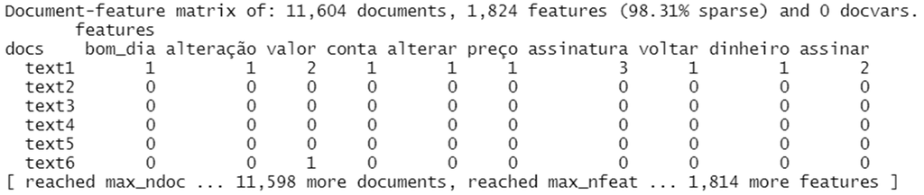

```r
knitr::include_graphics("document-term-matrix.png")
```

## Modeling

The number of topics (`k`) to be considered by the LDA algorithm must be specified by the analyst when defining the model.

Therefore, in order to find the optimal value for this parameter, we apply cross-validation: First, the dataset is randomly split into two subsets, so that 50% of the documents will be used to train the models and the remaining 50% to test the estimated models. Then, we train various LDA models varying the number of topics on the training set, and compute the “perplexity” measure for each model on the test set.

```r
n_topics <- c(2, 4, 10, 20, 40, 60, 80, 100, 150, 200)

# Creates the train and test sets
set.seed(1984)
splitter <- sample(1:dim(DTM)[1], round(dim(DTM)[1] * 0.5))
train <- DTM[splitter, ]
test <- DTM[-splitter, ]

eval_lda <- function(k){
  training_model <- LDA(train, k = k, method="Gibbs", control=list(iter = 500, seed = 1))
  test_model <- LDA(test, model = training_model, method="Gibbs", control = list(estimate.beta = FALSE, iter = 500, seed = 1))

  return(perplexity(test_model, newdata = test, estimate_theta=FALSE))
}

eval_out <- NULL

# Runs the cross-validation and saves the output in 'eval_out'
start_time <- Sys.time()

for (k in n_topics) {

    eval_out <- rbind(eval_out, c(ntopics=k, perplexity=eval_lda(k)))

    }

end_time <- Sys.time()
end_time - start_time
```

The result of this procedure is presented in the following figure, which corresponds to a graph with the “perplexity” values computed for each test model as a function of the number of topics considered in the model. It is observed that the perplexity value decreases as the number of topics increases, indicating an improvement in the generalization capacity of the model. It reaches its minimum value for 150 topics, but the gain with the increase in the number of topics begins to be increasingly smaller from 20 topics. This seems to be, then, an adequate number of topics to be defined for the corpus of this study.

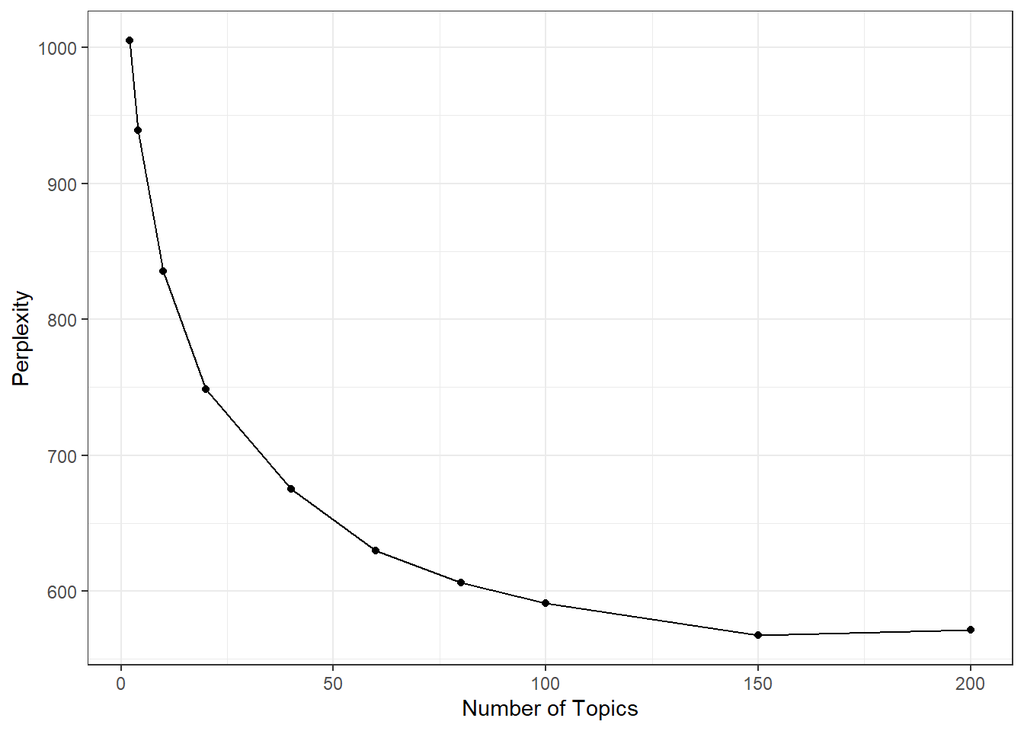

```r
# Viewing the results graphically
ggplot(as.data.frame(eval_out), aes(x=ntopics, y=perplexity)) +
  geom_line() +
  geom_point() +
  theme_bw() +
  labs(x = "Number of Topics",
       y = "Perplexity")
```

## Analysis

However, before making a final decision, let us compare the LDA models estimated for 20 and for 150 topics in order to assess the impact that the number of topics defined may have on the interpretability of the results. These two new models were estimated considering all the documents of the corpus and also using the “Gibbs Sampling” algorithm with 500 iterations.

```r
lda20 <- LDA(DTM, k = 20, method="Gibbs", control=list(iter = 500, seed = 1))
```

```r
lda150 <- LDA(DTM, k = 150, method="Gibbs", control=list(iter = 500, seed = 1))
```

To better compare the two models, we can use the visualizations generated by the `LDAvis` package.

```r
tmResult <- posterior(lda20) # Gets the posterior distributions
theta <- tmResult$topics
phi <- tmResult$terms
vocab <- colnames(phi)
doc_length <- apply(X = DTM, MARGIN = 1, FUN = sum)
term_frequency <- apply(X = DTM, MARGIN = 2, FUN = sum)

json <- createJSON(phi = phi,
                   theta = theta,
                   doc.length = doc_length,
                   vocab = vocab,
                   term.frequency = term_frequency, R=20)

serVis(json) # Opens the vis. on the browser
```

The result, presented in the following figures, shows the topics as circles in a two-dimensional graph, where the location of the center of each circle in the plane is determined by calculating the distance between the topics followed by multidimensional scaling and the area of the circles corresponds to the prevalence of the topics in the corpus. By the distance between the circles on this plane, it is then possible to get an overview of how topics are related to each other in the corpus. The greater proximity of topics in the plane indicates greater similarity between them with respect to the theme they represent.

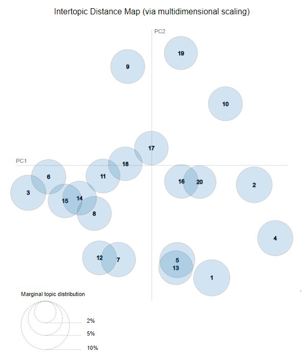

Intertopic Distance Map for the LDA model with 20 topics

```r
knitr::include_graphics("ldavis-20topics.png")
```

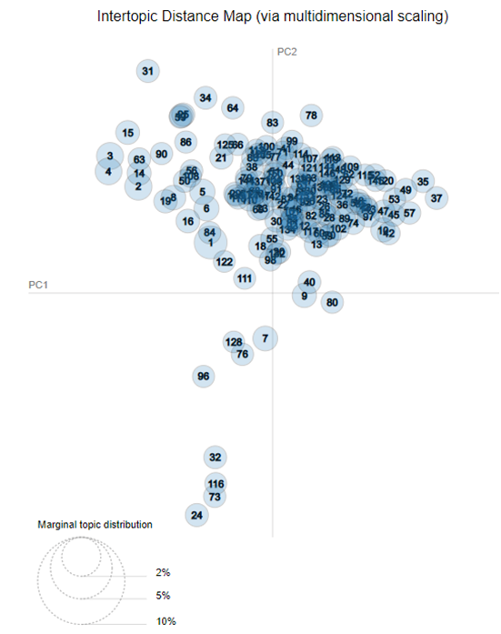

Intertopic Distance Map for the LDA model with 150 topics

```r
knitr::include_graphics("ldavis-150topics.png")
```

We can see that although the model with 150 topics has the lowest perplexity value among the models tested, the interpretability of the topics generated from this model was impaired, since many of these topics seem to be representing very similar themes. For this reason, the estimated model with 20 topics was selected to continue the study.

Check out the [interactive visualization](https://welldasilva.github.io/mba-usp-project/vis/) for the final model!

### Viewing the top terms for each topic

The next step is to interpret the topics generated by the LDA model, in order to identify the themes represented in each topic and have an overall view of the content of the complaints in the corpus.

We extract the 10 top-terms from the “terms given the topic” posterior distributions, based on the relevance measure (Sievert & Shirley, 2014), which normalizes the terms probabilities for their frequency in the corpus:

```r
tmResult <- posterior(lda20)
theta <- tmResult$topics
phi <- tmResult$terms
term_frequency <- apply(X = DTM, MARGIN = 2, FUN = sum)

# Calculates relevance
lambda <- 0.6
relevance <- lambda * log(phi) + (1 - lambda) * log(t(t(phi) / (term_frequency / sum(term_frequency)) ))

# Converts the matrix to a tidy table
relevance_tidy <- as_tibble(relevance) %>%
  mutate(topic=factor(row_number())) %>%
  relocate(topic) %>%
  pivot_longer(-topic,
               names_to="term",
               values_to="relevance")

# Finding the 10 terms that are most common within each topic
top_terms_byrelevance <- relevance_tidy %>%
  group_by(topic) %>%
  slice_max(relevance, n = 10) %>%
  ungroup() %>%
  arrange(topic, -relevance)
```

Let’s view the 10 top-terms for topic 6, which we can conclude that it relates to legal matters:

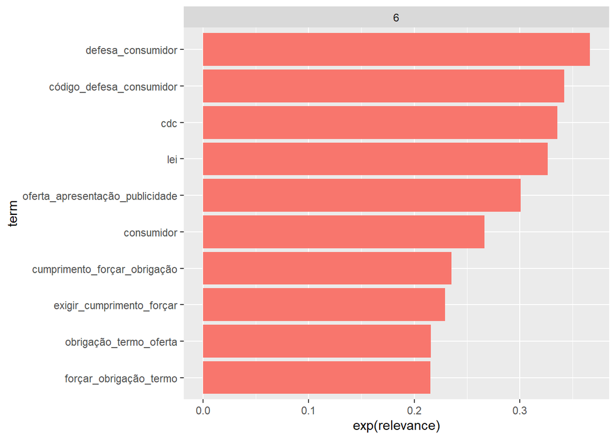

```r
# Ploting by choosing a topic
tn <- 6
top_terms_byrelevance %>%
  filter(topic == tn) %>%
  mutate(term = reorder_within(term, relevance, topic)) %>%
  ggplot(aes(exp(relevance), term, fill = factor(topic))) +
  geom_col(show.legend = FALSE) +
  facet_wrap(~ topic, scales = "free") +
  scale_y_reordered()
```

### Most prevalent topics in the corpus (Rank-1)

It is also extremely useful to identify which of the topics are most recurrent in the corpus, since this information can be used to direct efforts to improve the service offered to consumers towards the main problems they report.

For this, we count how many times a topic appears as the most dominant in a document:

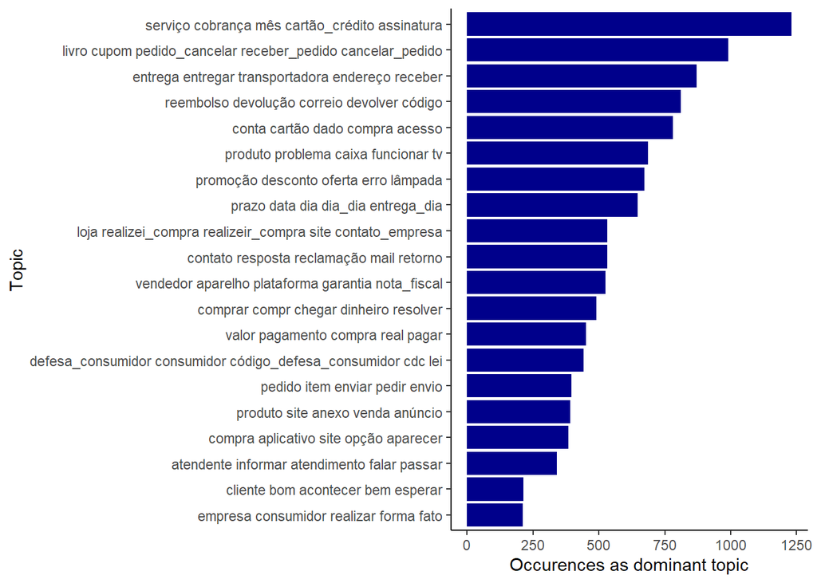

```r
## Assigns a name to the topics based on the 5 most relevant terms to help identify them
## NOTE: The ID of the topics in the "theta" matrix is different from that of the LDAvis result

# re-rank top topic terms for topic names
topicNames <- apply(lda::top.topic.words(topics = phi, num.words = 5, by.score = TRUE), 2, paste, collapse = " ")

# Counts how many times a topic is the most dominant in a document
countsOfPrimaryTopics <- rep(0, 20)
names(countsOfPrimaryTopics) <- topicNames
for (i in 1:nrow(theta)) {
  topicsPerDoc <- theta[i, ] # select topic distribution for document i
  # get first element position from ordered list
  primaryTopic <- order(topicsPerDoc, decreasing = TRUE)[1]
  countsOfPrimaryTopics[primaryTopic] <- countsOfPrimaryTopics[primaryTopic] + 1
}
countsOfPrimaryTopics <- sort(countsOfPrimaryTopics, decreasing = TRUE)

dominantTopics <- tibble::rownames_to_column(data.frame(countsOfPrimaryTopics), var = "topic")

ggplot(data = dominantTopics) +
  geom_col(aes(countsOfPrimaryTopics, fct_reorder(topic, countsOfPrimaryTopics)), show.legend = FALSE, fill = "darkblue") +
  labs(x = "Occurences as dominant topic", y = "Topic") +
  theme_classic()
```

We can see in the above figure that the most recurrent topic in the corpus is the one related to subscription to credit card services (topic 19), which appears as the most dominant in 1,231 complaints (corresponding to 10.61% of the corpus). The second most recurrent topic is topic 2, corresponding to order cancellations and discount coupons and present as the most dominant topic in 990 complaints (8.53% of the corpus). Topic 11, which refers to the delivery of orders, appears as the third most recurrent topic, being the dominant topic in 871 complaints, which corresponds to 7.51% of the corpus.

### Most Relevant Complaints per Topic Based on Dominance

As a way of verifying the validity of these topics (i.e. whether their most relevant terms actually make up the complaints in which they are most prevalent), the most representative complaint of each one was extracted, i.e. the document with the highest proportion of that topic:

```r
tmResult <- posterior(lda20) # Gets the posterior distributions
theta <- tmResult$topics
phi <- tmResult$terms
theta_t <- t(theta)

top_docs <- lda::top.topic.documents(document_sums = theta_t, num.documents = 1, alpha = attr(lda20, "alpha"))

# Gets the "names" of the documents
doc <- c()
for (t in top_docs) {
  doc[length(doc) + 1] <- colnames(theta_t)[t]
}

tidied_dtm <- tidy(DTM)

complaints <- tidied_dtm %>% group_by(document) %>% summarise(complaint = paste(term, collapse = " "))

top_comp <- c()

for (d in doc) {
  top_comp[length(top_comp) + 1] <- filter(complaints, document == d)[2]
}

topicNames <- apply(lda::top.topic.words(topics = phi, num.words = 5, by.score = TRUE), 2, paste, collapse = " ")
names(top_comp) <- topicNames

t(as.data.frame(top_comp)) %>%
  kable() %>%
  kable_styling(bootstrap_options = "none")
```

| compra.aplicativo.site.opção.aparecer | conta dinheiro despachar dia_recebi produto entrega entendi informação compra forma transportadora entregador solicitei cancelamento descobrir resolver_problema atendente fatura caso mensagem sac aces… |
| --- | --- |
| contato.resposta.reclamação.mail.retorno | devolver_dinheiro entrar_contato falar aparelho bom chat bloquear ligação protocolo mail telefone tentar_resolver maneira respeito varia entrar_contato_sac contato_sac ligueir produto_devolver bluetoo… |
| conta.cartão.dado.compra.acesso | conta solicitar informação compra endereço pedir absurdo fatura recebi abri constar cartão portanto valor_pagar necessário aplicativo novo tela online afirmar efetuei_compra continuar cancelar nome re… |
| entrega.entregar.transportadora.endereço.receber | conta pedido chegar pacote entregar entrega parte transportadora endereço entregador rua perguntar empresa pedir acontecer recusar constar cancelar_assinatura problema realizar_entrega cujo sistema si… |
| produto.problema.caixa.funcionar.tv | assinar outro mês fico_aguardo solicitar somente informação endereço casa serviço resolver_problema contato resolver recebi gostar solução aparentemente mensagem antigo comprar bom acesso canal pagame… |
| defesa_consumidor.consumidor.código_defesa_consumidor.cdc.lei | preço outro pedido produto informação compra parte cancelamento caso bom consumidor pagamento permitir portanto vista necessário precisar erro prezar bem referir qualidade comunicação prova ofertar cd… |
| promoção.desconto.oferta.erro.lâmpada | valor produto compra_produto pedir aproveitar receber_produto pedido_cancelar informar promoção dia_pedido_cancelar desconto print erro bem cancelar descontar reclamação adquiri surpresa anexar vender… |
| loja.realizei_compra.realizeir_compra.site.contato_empresa | solicitar prazo serviço empresa caso mensagem receber vendedor problema começar_apresentar_problema realizeir_compra efetuar_pagamento_quantia dia_útil sistema marca solucionar produto_começar_apresen… |
| comprar.compr.chegar.dinheiro.resolver | conta chegar prazo atrasar semana entregar_dia entrega achar compra casa valer presente compra_pedir mensagem infelizmente comprar acabar dia bom informar ultima data barato deixar principalmente temp… |
| pedido.item.enviar.pedir.envio | chegar pacote entrega pedir caixa item produto_entregar branco preto totalizar unidade vender anunciado quantidade pedido_produto baixo dia_pedido constatar ato |
| produto.site.anexo.venda.anúncio | outro nota_fiscal produto informação site errar receber_produto receber constar verificar chat atendimento item anexo realizei_compra produto_dia erro realizeir_compra gb efetuar_pagamento_quantia pag… |
| vendedor.aparelho.plataforma.garantia.nota_fiscal | mês resposta nota_fiscal chegar somente pedir prejuízo aparelho vendedor levar precisar celular em péssimo enviar atualização contato_vendedor cliente compr vender ano automático questionei entrar_con… |
| reembolso.devolução.correio.devolver.código | dinheiro outro pagar solicitar dia_recebi produto transportadora correio site serviço solicitei resolver devolver recebi caso devolução_produto dia informar estorno vendedor valor_pagar tempo prever n… |
| valor.pagamento.compra.real.pagar | valor pagar compra contato_telefone comprar_outro fatura estorno dia_recebi_mail pagamento autorizar realizei_compra novo atendente_informar efetuar_pagamento_quantia compra_realizar_site realizar_sit… |
| livro.cupom.pedido_cancelar.receber_pedido.cancelar_pedido | pedido somente produto filha livro compra forma parte perguntar site cancelamento resolver_problema empresa pedir valer acontecer atendente recebi mensagem dia bom canal consumidor durante promoção pa… |
| empresa.consumidor.realizar.forma.fato | conta solicitar pedido somente entrega livro compra transportadora parte_pedido site contato empresa valer método período absurdo pedido_cancelar dia durante empresa_dia pagamento data entrega_produto… |
| cliente.bom.acontecer.bem.esperar | conta dinheiro outro pedido entregar produto livro compra forma transportadora perguntar fico passar contato pedir acontecer atendente parar gostar infelizmente acabar bom item cartão deixar preciso p… |
| prazo.data.dia.dia_dia.entrega_dia | semana compra_produto informação entrega_dia pedir demorar dia estoque responder realmente contato_informar dia_realizeir_compra dia_útil cancelar_compra aguardar produto_disponível previsão_entrega_d… |
| atendente.informar.atendimento.falar.passar | resposta compra_produto transportadora histórico perguntar contato_telefone compra_dia entrega_dia empresa pedir período resolver atendente receber_produto recusar dia desconto ligação novo retornar c… |
| serviço.cobrança.mês.cartão_crédito.assinatura | alteração assinatura cobrar serviço solicitei contratar fatura informar estorno data music cartão cobrança aplicativo protocolo prezar vencimento outro_cartão reclamação final cobrar_cartão realizar_c… |